**Trial biostatistics toolkit**

OperationsBiostatisticsFull library

# TRIALMON: how the safety screens work

The rules behind the console and the SRC packet, each shown on the synthetic data

**Synthetic data.** Study CP-101 does not exist. TRIALMON flags positions for the medical monitor and the Safety Review Committee; it does not adjudicate a DLT or a Hy’s Law case, and it makes no dose-escalation decision. Each rule below is one function in `R/logic.R`, shared by the console, the snapshot, the SRC packet and the tests.

## The rules on one page

One definition per screen

| Screen | Definition | Source |
| --- | --- | --- |
| Potential Hy’s Law | ALT or AST >= 3x ULN, and total bilirubin (TBL) > 2x ULN on or after that draw within 30 days of it (an SAP convention). Every such draw opens its own window. ALP shown; ALP < 2x ULN in that draw only… | FDA DILI guidance (July 2009) |
| Aminotransferase confirmation | ALT or AST > 3x ULN: repeat ALT, AST, ALP and TBL within 48 to 72 hours. | FDA DILI guidance (July 2009) |
| eDISH quadrants | Peak post-baseline ALT or AST against peak TBL, both x ULN, lines at 3x and 2x. Peaks need not be concurrent. | Plotting convention |
| R ratio | (ALT/ULN)/(ALP/ULN) at the reported ALT or AST >= 3x ULN draw (the qualifying one for a potential Hy’s Law case, otherwise the first): >= 5 hepatocellular, 2 < R < 5 mixed, <= 2 cholestatic. | CIOMS/RUCAM convention |
| QTcF categories | Maximum post-baseline QTcF > 450, > 480, > 500 ms; maximum change > 30, > 60 ms. Screen: RED > 500 or > 60; AMBER > 480 or > 30; watch > 450. | ICH E14 (2005); E14 Q&A (R3) (2015); E14/S7B Q&As (2022) |
| Lab grades | Lab grades derived under NCI CTCAE v6.0 by default, v5.0 per protocol, named in every footnote. AE grades stay as the investigator recorded them. | NCI CTCAE v6.0 / v5.0 |
| DLT tally | 3+3 as an illustrative rule reference: 0 of 3 or 1 of 6 escalation-eligible; 1 of 3 expand to 6; 2 or more: the dose exceeds the MTD. | Illustrative only; BOIN noted below |
| Roll-up | Worst-of at participant (watch included), cohort, study tier and overall. Never an average. | TRIALMON design |

## Liver: a quadrant is not a case

A point in the upper-right eDISH quadrant means the participant’s *peak* aminotransferase reached 3x ULN and their *peak* bilirubin passed 2x ULN, but the two peaks can come weeks apart. The potential Hy’s Law screen adds the timing: bilirubin above 2x ULN on or after the aminotransferase elevation, within the window. Every draw with ALT or AST at least 3x ULN opens its own window, so a second rise weeks after the first is screened too. Separately, FDA’s guidance asks for a repeat of ALT, AST, ALP and TBL within 48 to 72 hours of any aminotransferase **above** 3x ULN, so a high ALT with normal bilirubin still gets a flag. It is not a Hy’s Law finding, and it is not green.

- **CP101-014**: ALT and AST at least 3x ULN from Day 15; bilirubin 3.1x ULN on Day 22, 7 days later; ALP 1.1x ULN. **Potential Hy’s Law** (RED).
- **CP101-009**: ALT 4.2x and AST 3.6x ULN on Day 15, bilirubin 1.6x ULN. Not Hy’s Law, but **confirm** (AMBER); the first repeat came 5 days later.
- **CP101-004**: upper-right on peaks, but bilirubin peaked on Day 4 and ALT on Day 22. Not Hy’s Law; the ALT elevation needs **confirmation** (AMBER).

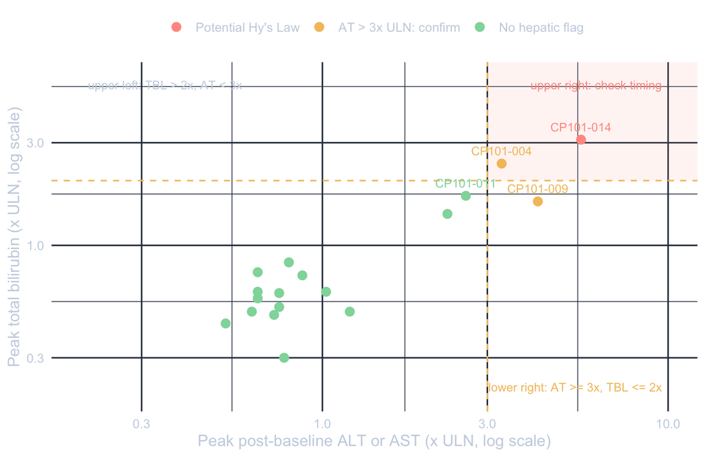

| Participant | Quadrant | ALT or AST >= 3x (day) | TBL > 2x on or after (day) | Potential Hy’s Law | Screen |
| --- | --- | --- | --- | --- | --- |
| CP101-004 | Upper right | 22 |  | No | AMBER |
| CP101-009 | Lower right | 15 |  | No | AMBER |
| CP101-014 | Upper right | 15 | 22 | Yes | RED |

Exactly 3x ULN counts for Hy’s Law (FDA: “3-fold or greater”), but the confirmation flag needs a value above 3x, as in the FDA text. Bilirubin must be above 2x ULN, so exactly 2x does not count. The tests pin each of these boundaries, including a second elevation 39 days after the first. The eDISH axes widen when a participant’s peak is beyond 10x ULN (AT) or 6x ULN (TBL), so no point falls off.

## QTcF: categories, not a verdict

| Category | C1 (N=3) | C2 (N=3) | C3 (N=6) | C4 (N=6) | Total (N=18) |
| --- | --- | --- | --- | --- | --- |
| QTcF > 450 ms | 0 (0%) | 1 (33%) | 2 (33%) | 1 (17%) | 4 (22%) |
| QTcF > 480 ms | 0 (0%) | 1 (33%) | 0 (0%) | 1 (17%) | 2 (11%) |
| QTcF > 500 ms | 0 (0%) | 0 (0%) | 0 (0%) | 1 (17%) | 1 (6%) |
| Change > 30 ms | 0 (0%) | 1 (33%) | 0 (0%) | 1 (17%) | 2 (11%) |
| Change > 60 ms | 0 (0%) | 0 (0%) | 0 (0%) | 0 (0%) | 0 (0%) |

Maximum post-baseline value per participant; categories are cumulative; a value equal to a threshold is not above it. ICH E14 and its Q&As use the same 450, 480 and 500 ms categories for both sexes. In the synthetic data CP101-018 reaches 503 ms (RED) and CP101-006 486 ms (AMBER); both started above 450 ms at baseline, which the packet reports alongside.

## Lab grades: name the CTCAE version

Grades come from multiples of the ULN or LLN, or from fold over baseline where the term says so, and the version changes the answer. Every lab footnote names it.

| Participant | Test | Situation | Grade, v5.0 | Grade, v6.0 |
| --- | --- | --- | --- | --- |
| CP101-013 | NEUT | Neutrophil nadir 0.9 x 10^9/L: v6.0 moved the cut points down | 3 | 2 |
| CP101-011 | CREAT | Creatinine 1.6x baseline, baseline normal, 1.07x ULN | 2 | 1 |
| CP101-017 | CREAT | Creatinine 1.67x baseline, baseline below the LLN | 2 | 2 |

NCI CTCAE v5.0 creatinine increased: grade 2 is more than 1.5 to 3.0x baseline or more than 1.5 to 3.0x ULN, so the grade is the worse of the two. In v6.0 the fold-over-baseline criterion applies only when the baseline is below the LLN. The v6.0 cut points used here follow admiral 1.5.0 (`atoxgr_criteria_ctcv6`); they were not re-checked against the NCI v6.0 workbook.

## Dose escalation: a rule reference, not a decision

| Cohort | Dose (mg) | Dosed | DLT-evaluable | DLTs | Pending | Illustrative 3+3 reference |
| --- | --- | --- | --- | --- | --- | --- |
| C1 | 10 | 3 | 3 | 0 | 0 | 0 of 3: escalation-eligible under the rule |
| C2 | 30 | 3 | 3 | 0 | 0 | 0 of 3: escalation-eligible under the rule |
| C3 | 60 | 6 | 6 | 1 | 0 | 1 of 6: escalation-eligible under the rule |
| C4 | 120 | 6 | 6 | 1 | 1 | 1 of 6 confirmed, 1 pending adjudication. If not a DLT: 1 of 6, escalation-eligible under the rule. If a DLT: 2 of 6, under the rule, the dose exceeds the MTD |
| C5 | 200 | 0 | 0 | 0 | 0 | not dosed |

The rule reads one DLT against its denominator: 1 of 3 means expand the cohort to 6; 1 of 6 is escalation-eligible; 2 or more mean the dose exceeds the MTD, which needs 6 treated participants. In Cohort 4 the reference depends on a pending adjudication, which is the committee’s call, and even “escalation-eligible” sits next to a potential Hy’s Law case at the same dose. 3+3 stays here only as an illustration. Model-assisted designs such as BOIN, which FDA determined fit for purpose in December 2021 (the local design under a non-informative prior), are the current alternative; TRIALMON does not implement them.

## Roll-up: the worst level wins

The earlier risk console averaged severity scores, so one red Hy’s Law signal among green ones rolled up to amber. TRIALMON takes the worst level at every step instead. Today the participant and cohort tier is RED and the study tier is AMBER, so the overall screen is RED. Setting every study-level indicator to green leaves the overall screen at RED: one RED participant is enough, and no number of greens dilutes it. The watch level (QTcF above 450 ms) is a worklist row too, so 2 participants at watch would keep the participant tier at watch even if every RED and AMBER flag were cleared.

## Run it

```r
install.packages(c("shiny", "bslib", "DT", "ggplot2"))
shiny::runApp("sasr_monitoring_wiki/trialmon_shiny")
Rscript sasr_monitoring_wiki/trialmon_tests/run-tests.R     # needs testthat
```

The run-and-build page lists every line of the app, the rules and the tests.